# PhD vs. M.S. advisor’s most recent publication: A text analysis

Julianna Renzi

2/17/2021

In this script I compare the words used in the most recent peer-reviewed paper by my PhD and Master’s adviser, where they were the senior (i.e. last) author. Although the lexicons and tools here are primarily for non-academic texts, this is a fun exercise to demonstrate what we can do with words in `R`.

## PhD advisor: Deron Burkepile

Read in my PhD adviser’s latest relevant publication, which was led by Dr. Leïla Ezzat.

**Citation:** - Ezzat, L., Lamy, T., Maher, R.L., Munsterman, K.S., Landfield, K.M., Schmeltzer, E.R., Clements, C.S., Thurber, R.L.V. and Burkepile, D.E., 2020. Parrotfish predation drives distinct microbial communities in reef-building corals. Animal Microbiome, 2(1), p.5.

### Prepare the data

```r
ezzat_text <- pdf_text("Ezzat_et_al_2020.pdf")
```

First, split the text up by line and trim excess white space

```r
ezzat_tidy <- data.frame(ezzat_text) %>% # now each row is a different page
  mutate(text_full = str_split(ezzat_text, pattern = "\\n")) %>% # first slash just says look for \n as a string
# break it up using string split breaking wherever there is a line break
# now each line is an element -- then want each element
  unnest(text_full) %>% # now see repeated information but each line has it's own line
  mutate(text_full = str_trim(text_full)) %>% # get rid of excess white spaces
  slice(-1:-11) %>% # get rid of front matter/authors
  slice(-25:-37) %>% # remove license etc.
  slice(-545:-n()) %>% # remove supplement and citations
  slice(-1:-24) # also post-facto decide to remove abstract/just focus on main text
```

Then break up the PDF into logical sections for analysis

```r
# break up the manuscript by traditional sections
ezzat_df <- ezzat_tidy %>%
  mutate(section = ifelse(str_detect(text_full, pattern = "Background"), "Introduction",
                  ifelse(str_detect(text_full, pattern = "Results"), "Results",
                  ifelse(str_detect(text_full, pattern = "Conclusion"), "Conclusion",
                  ifelse(str_detect(text_full, pattern = "Material and methods"), "Methods",

                          NA_character_))))) %>%
  fill(section) # fills in the NAs with the value above
  # need to know this is in order to use fill()
```

Remove numbers, citations, and figure/table references. Then get the data into tokenized text format, where one token is one single word using `tidytext`.

```r
ezzat_tokens <- ezzat_df %>%
  mutate(text_full = gsub(x = text_full, pattern = "[0-9]+|[[:punct:]]|\\(.*\\)", replacement = "")) %>% # first get rid of numbers and citations because we are only analyzing the text
  # then remove Fig and Table labels
  mutate(text_full = gsub(x = text_full, pattern = "Fig.", replacement = "")) %>%
  mutate(text_full = gsub(x = text_full, pattern = "Tables", replacement = "")) %>%
  mutate(text_full = gsub(x = text_full, pattern = "Table", replacement = "")) %>%
  mutate(text_full = gsub(x = text_full, pattern = "Figure", replacement = "")) %>%
  mutate(text_full = gsub(x = text_full, pattern = "Figures", replacement = "")) %>%

  unnest_tokens(word, text_full) %>% # from tidytext
  select(-ezzat_text) # get rid of first column that holds no new information
```

Now remove stop words (i.e. common words like “the”, “is”, and “it”)

```r
ezzat_nonstop_words <- ezzat_tokens %>%
  anti_join(stop_words) # knows to un-join by matching column name
# use ?stop_words to look at different stop_words lexicons


# count them by section (this is equivalent to group_by + summarize)
nonstop_counts <- ezzat_nonstop_words %>%
  count(section, word)

# find the top 10 words by section
top_10_words <- nonstop_counts %>%
  group_by(section) %>%
  arrange(-n) %>%
  slice(1:10) # keep top ten

top_10_words
```

```
## # A tibble: 40 x 3
## # Groups:   section [4]
##    section    word            n
##    <chr>      <chr>       <int>
##  1 Conclusion coral          11
##  2 Conclusion corals          9
##  3 Conclusion parrotfish      8
##  4 Conclusion fish            4
##  5 Conclusion lobata          4
##  6 Conclusion microbiomes     4
##  7 Conclusion collected       3
##  8 Conclusion colonies        3
##  9 Conclusion colony          3
## 10 Conclusion corallivory     3
## # … with 30 more rows
```

### Visualize results

Visualize the top words

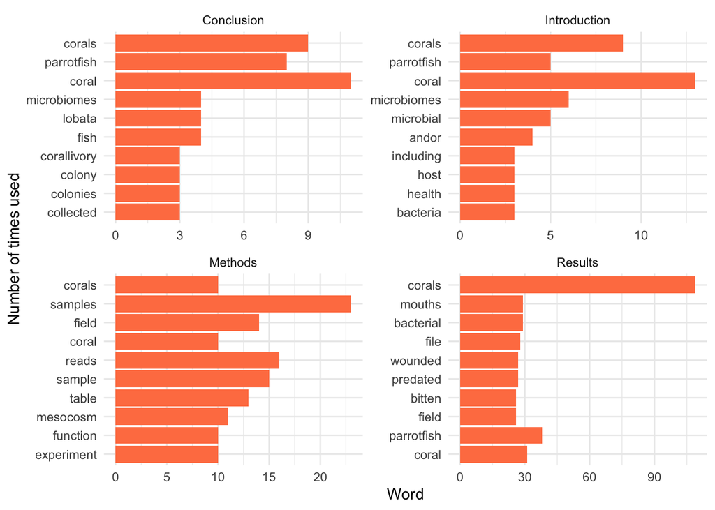

```r
ggplot(data = top_10_words, aes(x = reorder(word, n), y = n)) +
  geom_col(fill = "coral") +
  facet_wrap(~section, scales = "free") + # need scales = "free" to make it so axes (incl. x axis) is not the same in each plot
  coord_flip() +
  ylab("Word") +
  xlab("Number of times used") +
  theme_minimal()
```

Make word clouds of the top 50 words in each section

```r
intro_top50 <-
  nonstop_counts %>%
  filter(section == "Introduction") %>%
  arrange(-n) %>%
  slice(1:50)

intro_cloud_Der <- ggplot(data = intro_top50, aes(label = word)) +
  geom_text_wordcloud(aes(color = n, size = n)) +
  scale_size_area(max_size = 6) +
  ggtitle('Burkepile') +
  theme_void()

# see some words got cut off, but we'll leave those be for now
```

```r
# can make one for methods
methods_top50 <-
  nonstop_counts %>%
  filter(section == "Methods") %>%
  arrange(-n) %>%
  slice(1:50)

meth_cloud_Der <- ggplot(data = methods_top50, aes(label = word)) +
  geom_text_wordcloud(aes(color = n, size = n)) +
  scale_colour_continuous(type = "viridis") +
  scale_size_area(max_size = 6) +
  theme_void() +
  ggtitle('Burkepile')



# or one for results
results_top50 <-
  nonstop_counts %>%
  filter(section == "Results") %>%
  arrange(-n) %>%
  slice(1:50)

res_cloud_Der <- ggplot(data = results_top50, aes(label = word)) +
  geom_text_wordcloud(aes(color = n, size = n)) +
  scale_colour_continuous(type = "gradient", low = "grey", high = "coral") +
  scale_size_area(max_size = 6) +
  theme_void() +
  ggtitle('Burkepile')


# or for the conclusion
concl_top50 <-
  nonstop_counts %>%
  filter(section == "Conclusion") %>%
  arrange(-n) %>%
  slice(1:50)

concl_cloud_Der <- ggplot(data = concl_top50, aes(label = word)) +
  geom_text_wordcloud(aes(color = n, size = n)) +
  scale_colour_continuous(type = "gradient", low = "orange", high = "darkorchid") +
  scale_size_area(max_size = 6) +
  theme_void() +
  ggtitle('Burkepile')
```

### Conduct a sentiment analysis

Although this is not as relevant for academic papers like Ezzat et al., I’ll conduct a sentiment analysis for fun where we look at whether the words used have positive or negative connotations. This will be biased given that Ezzat et al. is talking about predation/wounding (and given that the lexicons are not meant for this kind of writing), but is a fun exercise.

I’ll use the afinn lexicon that ranks words on a scale of -5 (very negative) to 5 (very positive). We’ll only keep words that have a counterpart in the afinn lexicon, which will dramatically change the words we analyze (again, this is better for other forms of text, but I thought it would be interesting anyways).

```r
afinn_lex <- get_sentiments("afinn")

# join matching words
ezzat_afinn <- ezzat_nonstop_words %>%
  inner_join(get_sentiments("afinn"))

# can get total counts
afinn_counts <- ezzat_afinn %>%
  count(section, value) # see how positive and negative the values are for each section

# or could get mean value
afinn_means <- ezzat_afinn %>%
  group_by(section) %>%
  summarize(mean_afinn = mean(value))
```

Visualize results

```r
afinn_Der <- ggplot(data = afinn_means, aes(x = reorder(section, mean_afinn), y = mean_afinn)) +
  geom_col(fill = "coral") +
  ylab("Mean afinn value (-5 to 5)") +
  xlab("Paper section") +
  coord_flip() +
  scale_y_continuous(limits = c(-1,1)) +
  theme_bw() +
  geom_vline(aes(xintercept = 0)) +
  ggtitle("Burkepile")
```

Or we could use a different lexicon, like the NRC lexicon.

```r
ezzat_nrc <- ezzat_nonstop_words %>%
  inner_join(get_sentiments("nrc")) # have repeated values when there are multiple sentiments for a word

ezzat_nrc_counts <- ezzat_nrc %>%
  count(section, sentiment) # 10 sentiments total in nrc

nrc_Der <- ezzat_nrc_counts %>%
  ggplot(aes(x = reorder(sentiment, n), y = n)) +
  geom_col(fill = "coral") +
  facet_wrap(~section) +
  coord_flip() +
  xlab("Seniment") +
  ylab("Word count") +
  theme_minimal() +
  ggtitle("Burkepile") # these are only words that have a value in the nrc lexicon
```

## M.S. advisor: Brian Silliman

Read in my M.S. adviser’s latest relevant publication, which was led by Dr. Qiang He.

**Citation:** - He, Q., Li, H., Xu, C., Sun, Q., Bertness, M.D., Fang, C., Li, B. and Silliman, B.R., 2020. Consumer regulation of the carbon cycle in coastal wetland ecosystems. Philosophical Transactions of the Royal Society B, 375(1814), p.20190451.

### Prepare the data

```r
he_text <- pdf_text("He_et_al_2020.pdf")
```

First, split the text up by line and trim excess white space

```r
he_tidy <- data.frame(he_text) %>%
  mutate(text_full = str_split(he_text, pattern = "\\n")) %>%
  unnest(text_full) %>%
  mutate(text_full = str_trim(text_full)) %>% # get rid of excess white spaces
  slice(-1:-43) %>% # get rid of front matter/authors/abstract
  slice(-500:-n()) # remove citations, etc.
```

Then break up the PDF into logical sections for analysis

```r
# break up the manuscript by traditional sections
# these are slightly different than Ezzat et al, but we'll keep the names consistent
he_df <- he_tidy %>%
  mutate(section = ifelse(str_detect(text_full, pattern = "1. Introduction"), "Introduction",
                  ifelse(str_detect(text_full, pattern = "2. Materials and methods"), "Methods",
                  ifelse(str_detect(text_full, pattern = "3. Results"), "Results",
                  ifelse(str_detect(text_full, pattern = "4. Discussion"), "Conclusion",

                          NA_character_))))) %>%
  fill(section)
```

Remove numbers, citations, and figure/table references. Then get the data into tokenized text format, where one token is one single word using `tidytext`.

```r
he_tokens <- he_df %>%
  mutate(text_full = gsub(x = text_full, pattern = "[0-9]+|[[:punct:]]|\\(.*\\)", replacement = "")) %>% # first get rid of numbers and citations because we are only analyzing the text
  # then remove Fig and Table labels and other artifacts
  mutate(text_full = gsub(x = text_full, pattern = "figure", replacement = "")) %>%
  mutate(text_full = gsub(x = text_full, pattern = "figures", replacement = "")) %>%
  mutate(text_full = gsub(x = text_full, pattern = "table", replacement = "")) %>%
  mutate(text_full = gsub(x = text_full, pattern = "tables", replacement = "")) %>%
  mutate(text_full = gsub(x = text_full, pattern = "Phil. Trans. R. Soc. B", replacement = "")) %>%
  mutate(text_full = gsub(x = text_full, pattern = "royalsocietypublishing.org/journal/rstb", replacement = "")) %>%
  mutate(text_full = gsub(x = text_full, pattern = "royalsocietypublishingorgjournalrstb", replacement = "")) %>%

  unnest_tokens(word, text_full) %>% # from tidytext
  select(-he_text) # get rid of first column that holds no new information
```

Now remove stop words (i.e. common words like “the”, “is”, and “it”)

```r
he_nonstop_words <- he_tokens %>%
  anti_join(stop_words)


# count them by section (this is equivalent to group_by + summarize)
nonstop_counts <- he_nonstop_words %>%
  count(section, word)

# find the top 10 words by section
top_10_words <- nonstop_counts %>%
  group_by(section) %>%
  arrange(-n) %>%
  slice(1:10) # keep top ten

top_10_words
```

```
## # A tibble: 40 x 3
## # Groups:   section [4]
##    section    word           n
##    <chr>      <chr>      <int>
##  1 Conclusion carbon        40
##  2 Conclusion herbivores    26
##  3 Conclusion effects       21
##  4 Conclusion coastal       20
##  5 Conclusion cycle         18
##  6 Conclusion processes     15
##  7 Conclusion wetlands      15
##  8 Conclusion consumers     14
##  9 Conclusion soil          13
## 10 Conclusion herbivore     12
## # … with 30 more rows
```

### Visualize results

Visualize the top words

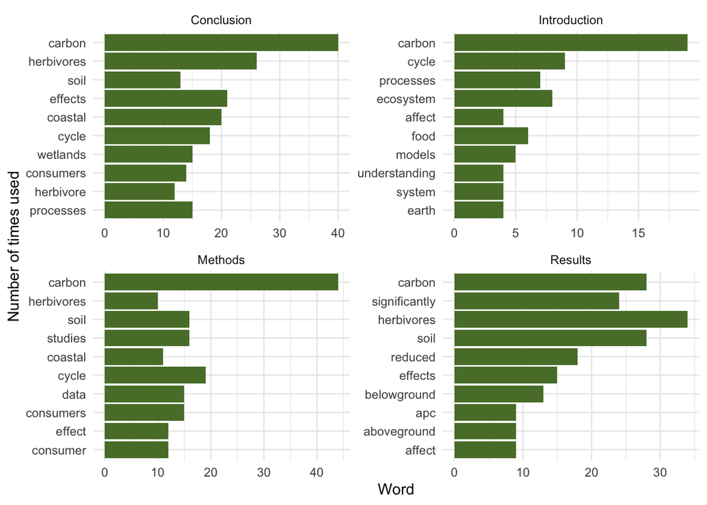

```r
ggplot(data = top_10_words, aes(x = reorder(word, n), y = n)) +
  geom_col(fill = "#597D35") +
  facet_wrap(~section, scales = "free") + # need scales = "free" to make it so axes (incl. x axis) is not the same in each plot
  coord_flip() +
  ylab("Word") +
  xlab("Number of times used") +
  theme_minimal()
```

Make word clouds of the top 50 words in each section

```r
intro_top50 <-
  nonstop_counts %>%
  filter(section == "Introduction") %>%
  arrange(-n) %>%
  slice(1:50)

intro_cloud_Sill <- ggplot(data = intro_top50, aes(label = word)) +
  geom_text_wordcloud(aes(color = n, size = n)) +
  scale_size_area(max_size = 6) +
  ggtitle('Silliman') +
  theme_void()
# see some words got cut off, but we'll leave those be for now
```

```r
# can make one for methods
methods_top50 <-
  nonstop_counts %>%
  filter(section == "Methods") %>%
  arrange(-n) %>%
  slice(1:50)

meth_cloud_Sill <- methods_cloud <- ggplot(data = methods_top50, aes(label = word)) +
  geom_text_wordcloud(aes(color = n, size = n)) +
  scale_colour_continuous(type = "viridis") +
  scale_size_area(max_size = 6) +
  ggtitle('Silliman') +
  theme_void()


# or one for results
results_top50 <-
  nonstop_counts %>%
  filter(section == "Results") %>%
  arrange(-n) %>%
  slice(1:50)

res_cloud_Sill <- ggplot(data = results_top50, aes(label = word)) +
  geom_text_wordcloud(aes(color = n, size = n)) +
  scale_colour_continuous(type = "gradient", low = "grey", high = "coral") +
  scale_size_area(max_size = 6) +
  ggtitle('Silliman') +
  theme_void()



# or for the conclusion
concl_top50 <-
  nonstop_counts %>%
  filter(section == "Conclusion") %>%
  arrange(-n) %>%
  slice(1:50)

concl_cloud_Sill <- ggplot(data = concl_top50, aes(label = word)) +
  geom_text_wordcloud(aes(color = n, size = n)) +
  scale_colour_continuous(type = "gradient", low = "orange", high = "darkorchid") +
  scale_size_area(max_size = 6) +
  ggtitle('Silliman')  +
  theme_void()
```

Plot them together to compare:

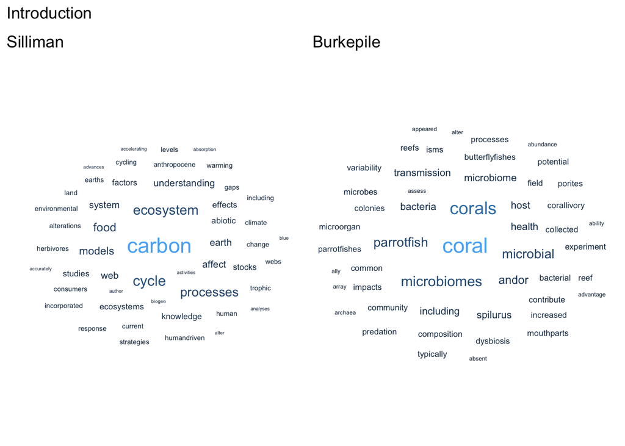

```r
(intro_cloud_Sill + intro_cloud_Der) + plot_annotation(
  title = 'Introduction')
```

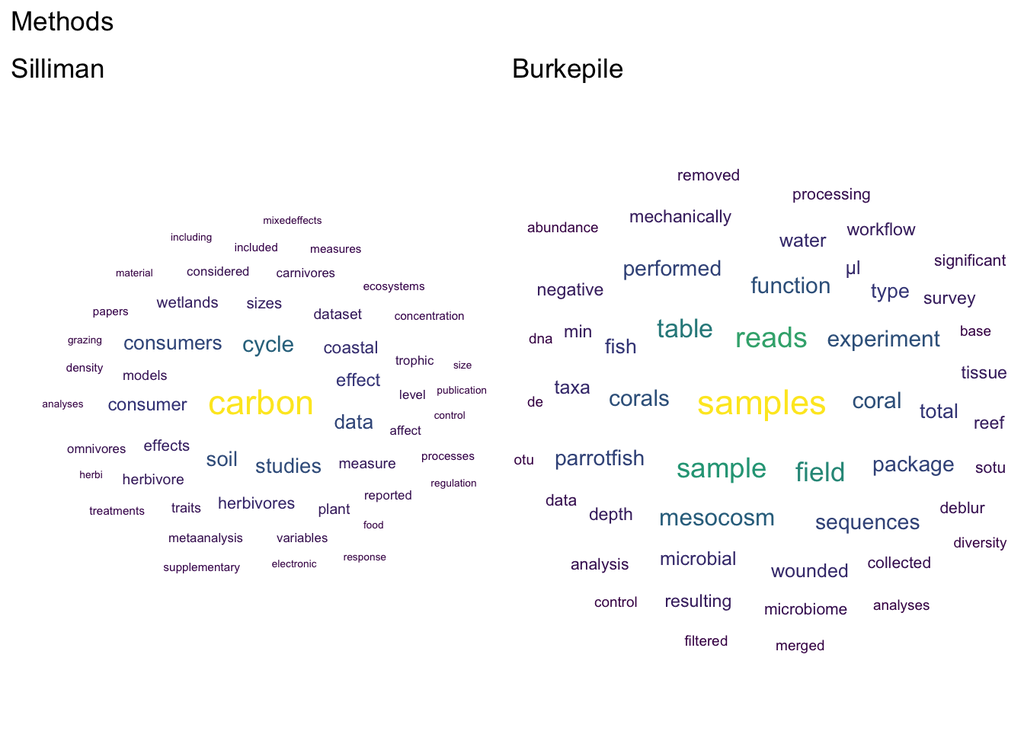

```r
(meth_cloud_Sill + meth_cloud_Der) + plot_annotation(
  title = 'Methods')
```

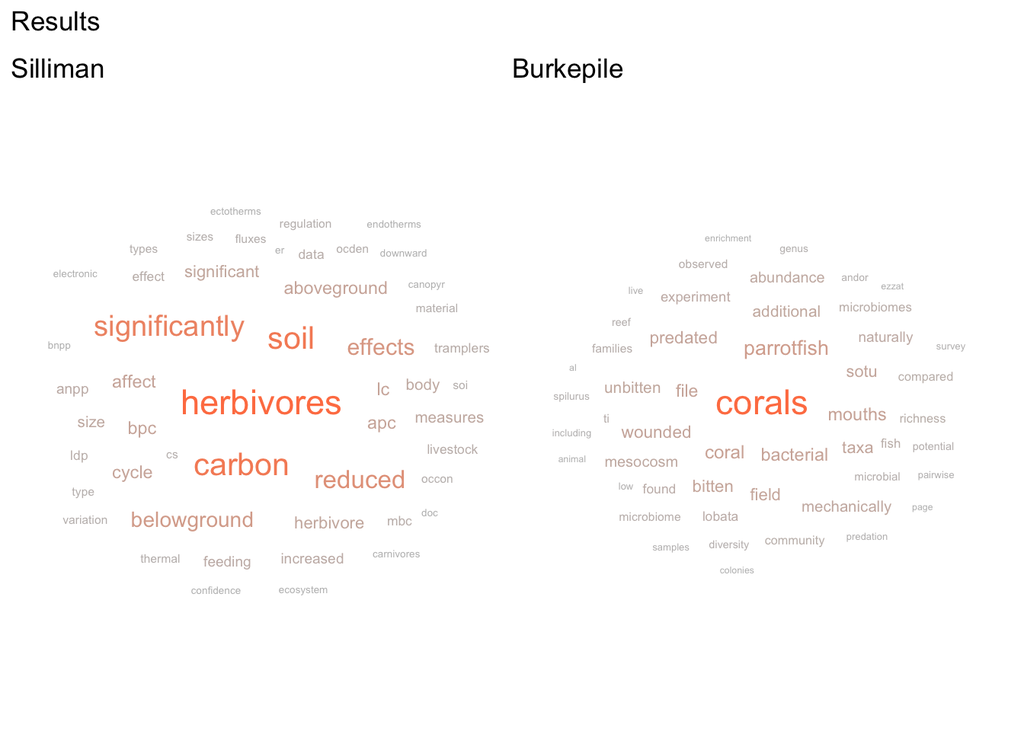

```r
(res_cloud_Sill + res_cloud_Der) + plot_annotation(
  title = 'Results')
```

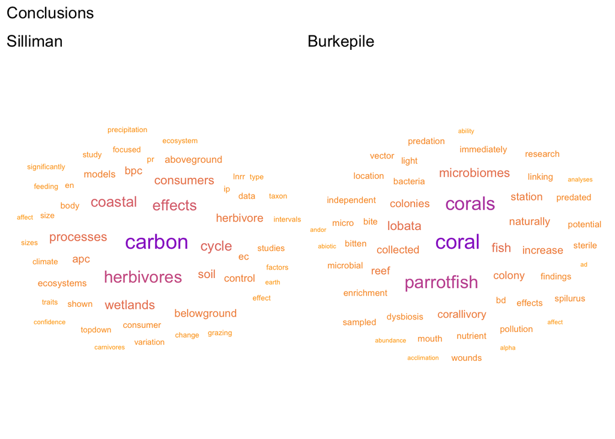

```r
(concl_cloud_Sill + concl_cloud_Der) + plot_annotation(
  title = 'Conclusions')
```

### Conduct a sentiment analysis

Again starting with the afinn lexicon that ranks words as positive or negative from a scale of -5 to 5

```r
afinn_lex <- get_sentiments("afinn")

# join matching words
he_afinn <- he_nonstop_words %>%
  inner_join(get_sentiments("afinn"))

# can get total counts
afinn_counts <- he_afinn %>%
  count(section, value) # see how positive and negative the values are for each section

# or could get mean value
afinn_means <- he_afinn %>%
  group_by(section) %>%
  summarize(mean_afinn = mean(value))
```

Visualize results

```r
afinn_Sill <- ggplot(data = afinn_means, aes(x = reorder(section, mean_afinn), y = as.numeric(mean_afinn))) +
  geom_col(fill = "#597D35") +
  ylab("Mean afinn value (-5 to 5)") +
  xlab("Paper section") +
  coord_flip() +
  scale_y_continuous(limits = c(-1,1)) +
  theme_bw() +
  geom_vline(aes(xintercept = 0)) +
  ggtitle("Silliman")
```

Plot them together for comparison

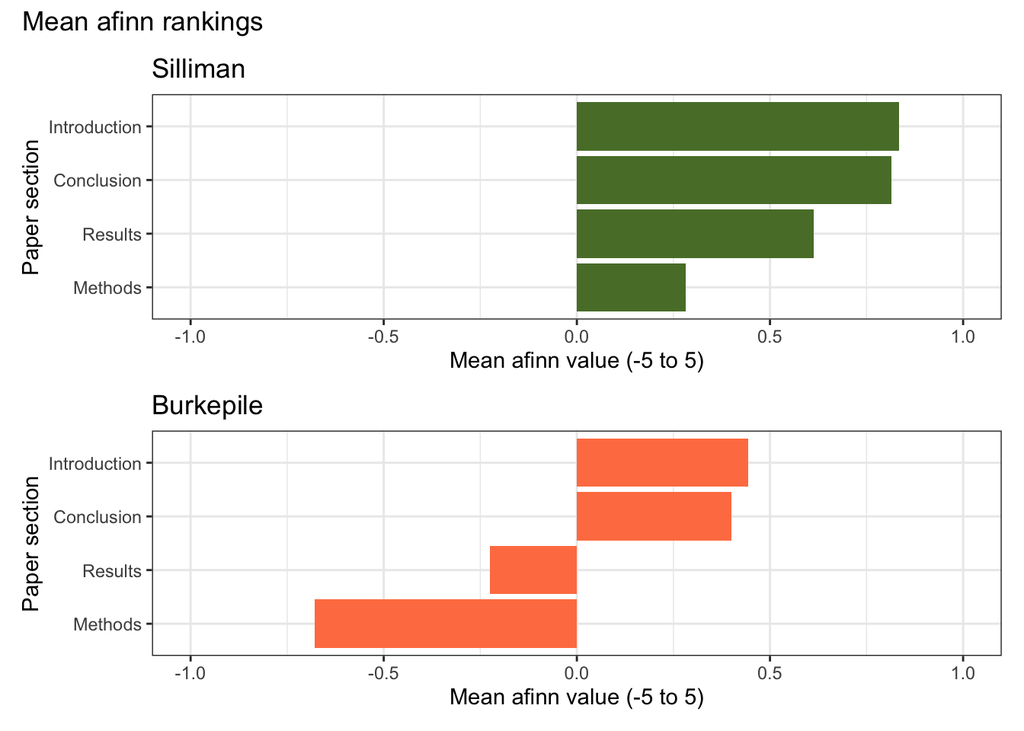

```r
afinn_Sill / afinn_Der + plot_annotation(
  title = "Mean afinn rankings")
```

Then we use the NRC lexicon again.

```r
he_nrc <- he_nonstop_words %>%
  inner_join(get_sentiments("nrc")) # have repeated values when there are multiple sentiments for a word

he_nrc_counts <- he_nrc %>%
  count(section, sentiment) # 10 sentiments total in nrc

nrc_Sill <- he_nrc_counts %>%
  ggplot(aes(x = reorder(sentiment, n), y = n)) +
  geom_col(fill = "#597D35") +
  facet_wrap(~section) +
  coord_flip() +
  xlab("Seniment") +
  ylab("Word count") +
  theme_minimal() +
  ggtitle("Silliman")
```

Plot them together

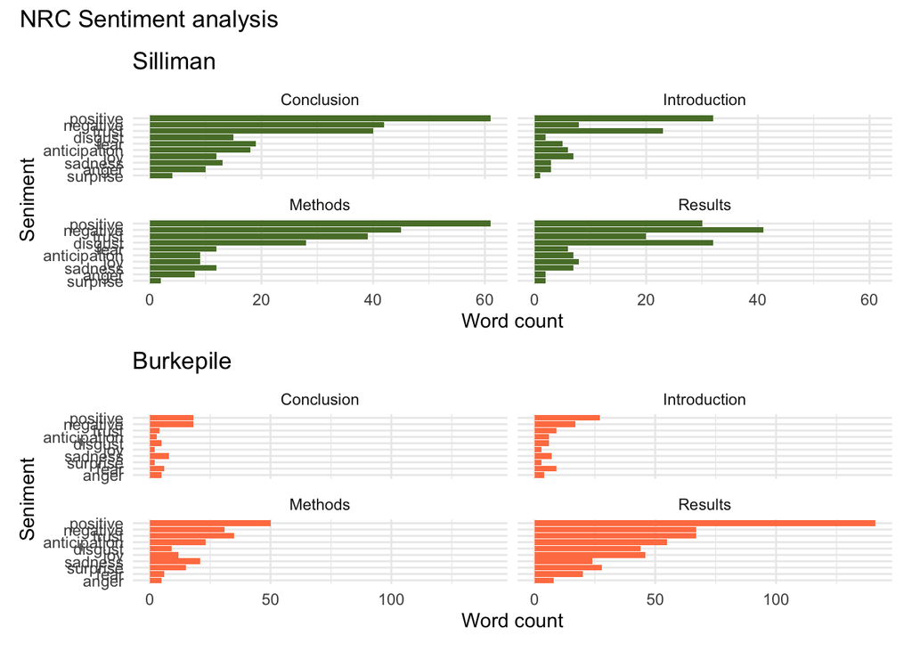

```r
(nrc_Sill / nrc_Der) + plot_annotation(
  title = "NRC Sentiment analysis"
) +
  plot_layout(widths = c(4, 4), heights = c(26, 26))
```